# week 5

Chong Zhang

February 9, 2018

# explore the data

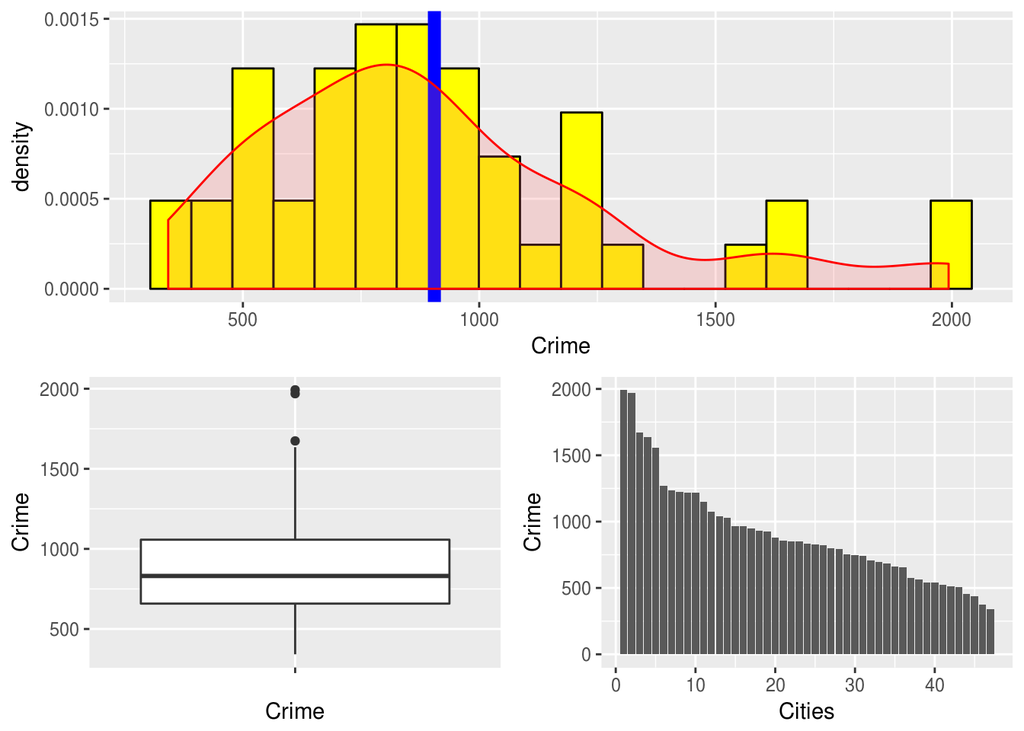

```r
library(dplyr)
library(ggplot2)
library(outliers)
library(gridExtra)
crime = read.table(file = 'uscrime.txt', sep = '', header = T)

# arange the data in a descending manner
crime_desc = arrange(crime, desc(Crime))
# plot the data with boxpolt
p1 = ggplot(data = crime_desc, aes(x = '', y =Crime))+geom_boxplot()+xlab('Crime')

p2 = ggplot(data = crime_desc, aes(x = 1:47, y =Crime))+geom_bar(stat="identity")+labs(x = 'Cities')

p3 = ggplot(data = crime_desc, aes(x =Crime))+
  geom_histogram(aes(y=..density..), colour="black", fill="yellow", bins = 20)+
  geom_vline(aes(xintercept=mean(Crime)), color = 'blue', size = 3)+
  geom_density(color = 'red', fill="#FF6666", alpha = 0.2)

grid.arrange(p3, arrangeGrob(p1,p2, ncol =2),ncol=1)
```

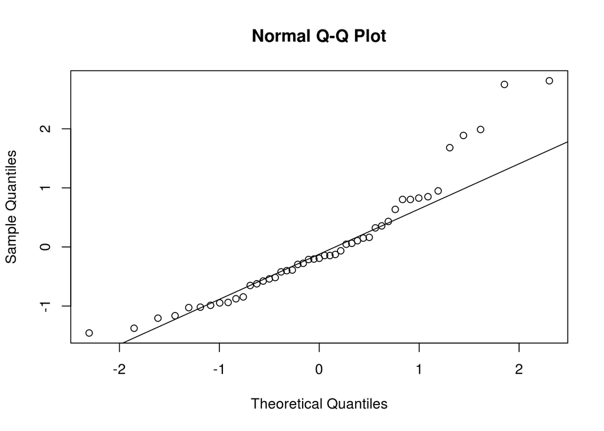

```r
qqnorm(scale(crime$Crime))
qqline(scale(crime$Crime))
```

From the boxplot, we see there are couple of cities that have crime rates higher than the rest of the data. It might indicate that there data point could be outliers.

From bar plot, we see that there is a dramatic decrease in crime after the first two and five cities.

From the histogram, we see that the data, overall, seems to be normally distributed, with extended right tail. It keeps wonder which those cities are. Mightbe Chicago or Baltimore? I heard from the news that the last year, the homicide rate in Chicago skyrocked.

From the Quantile-Quantile Plot, we can see that over all the samples are normally distributed. With some exceptions at the higher end.

## test whether there are outliers.

```r
result = grubbs.test(x = crime_desc$Crime, type = 10, opposite = FALSE)
print (result$alternative)
```

```
## [1] "highest value 1993 is an outlier"
```

```r
print (result$p.value)
```

```
## [1] 0.07887486
```

```r
result = grubbs.test(x = crime_desc$Crime, type = 10, opposite = TRUE)
print (result$alternative)
```

```
## [1] "lowest value 342 is an outlier"
```

```r
print (result$p.value)
```

```
## [1] 1
```

Based on the p-value of the test, **neither the highest or lowest crime cities are outliers**, if we set the thershold at **p<0.05** to reject the null hypothesis However, 0.0788 is quite close to 0.05, and visually there are couple of data are seemed to be outliers. So I decided to easy-up the criteria. I decide to set the thershold to **0.1**. In this case, the highest value 1993 is an outlier. Then I go on to test whether the second highest number is outlier or not. For this process, I will use a for loop to remove the outliers until p.value goes beyond 0.1

```r
outliers = c()
for (i in 1:length(crime_desc$Crime)){
  if (i == 1){
    result = grubbs.test(x = crime_desc$Crime, type = 10, opposite = F)
    if (result$p.value < 0.1){
    outliers = c(outliers,crime_desc$Crime[i])
    }
  }
  else{
    result = grubbs.test(x = crime_desc$Crime[-c(1:i-1)], type = 10, opposite = F)
    if (result$p.value < 0.1){
    outliers = c(outliers,crime_desc$Crime[i])
    }
    if ((result$p.value > 0.1)){
      break
    }
  }
}
print (outliers)
```

```
## [1] 1993 1969
```

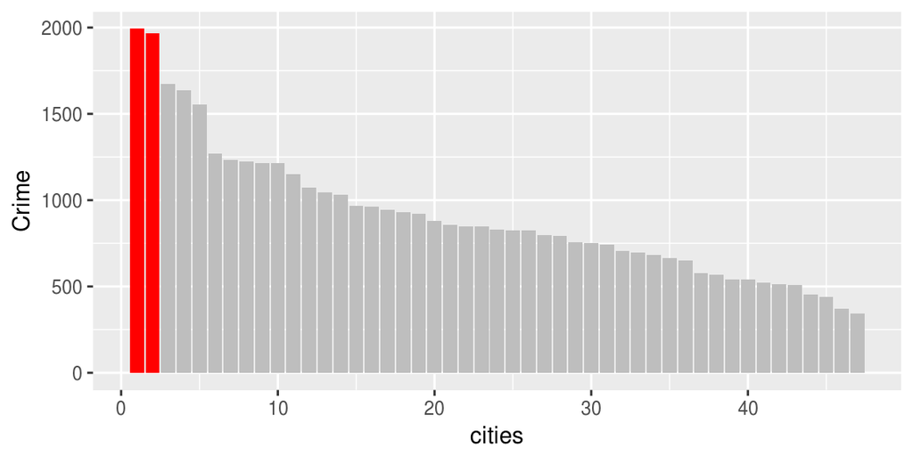

```r
p = ggplot(data = crime_desc, aes(x = 1:47, y =Crime))+geom_bar(stat="identity",aes(fill = Crime<outliers[2]))+labs(x = 'cities')
p = p + scale_fill_manual(values = c('red','grey'))+ theme(legend.position="none")
p
```

```r
#remove the outliers
crime_desc = crime_desc[-c(1,2),]
```

Thus `1993, 1969` are outliers. Thus those two data points should be removed from the whole data set.

# look at the relationship between each predictor and the crime

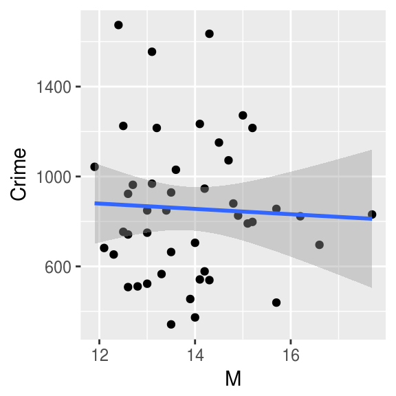

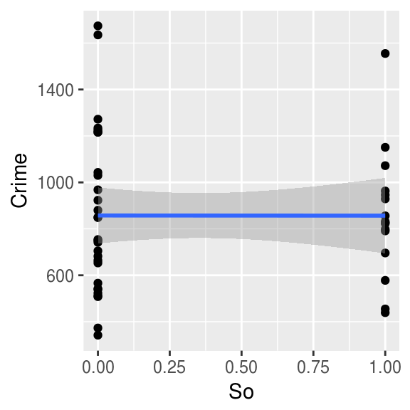

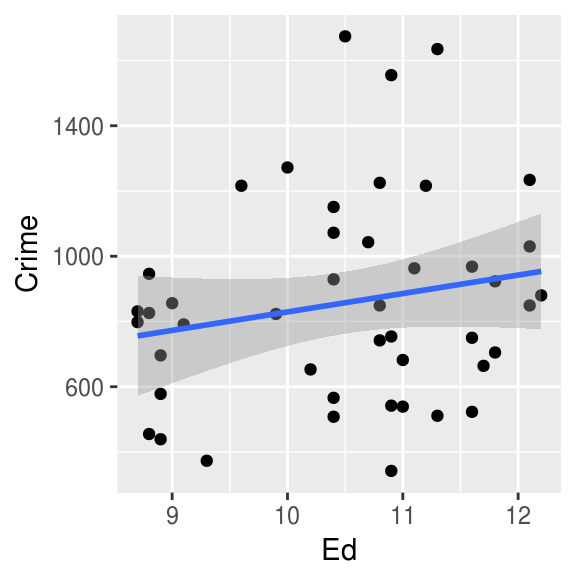

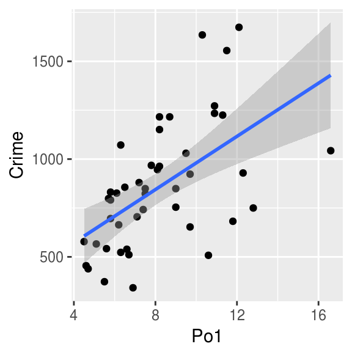

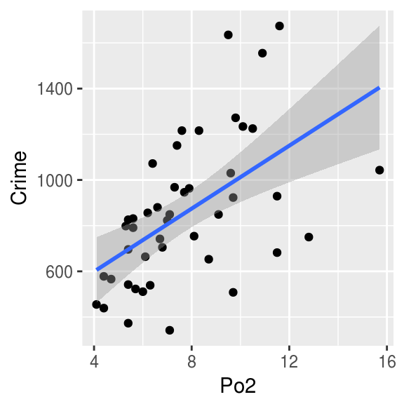

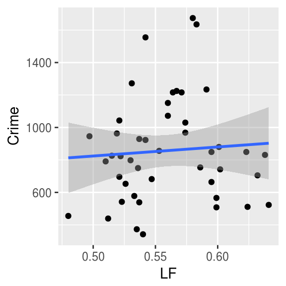

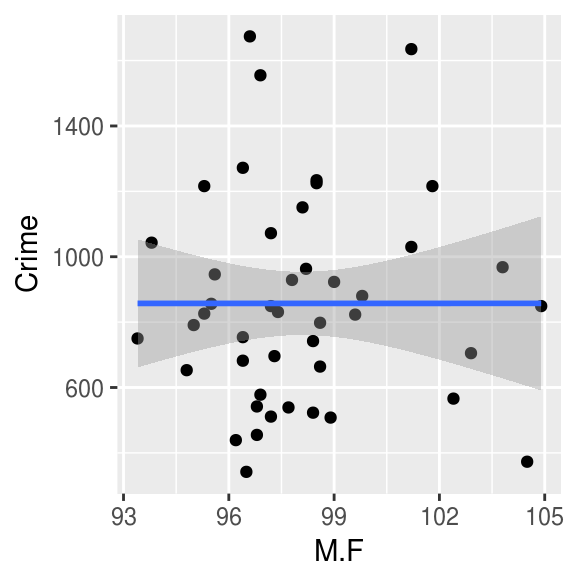

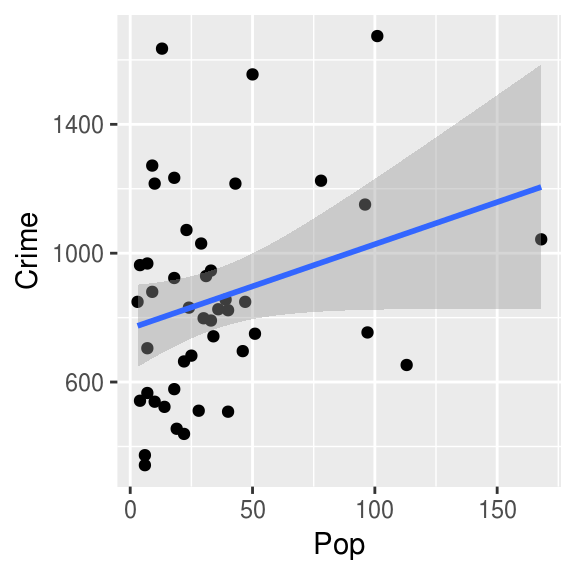

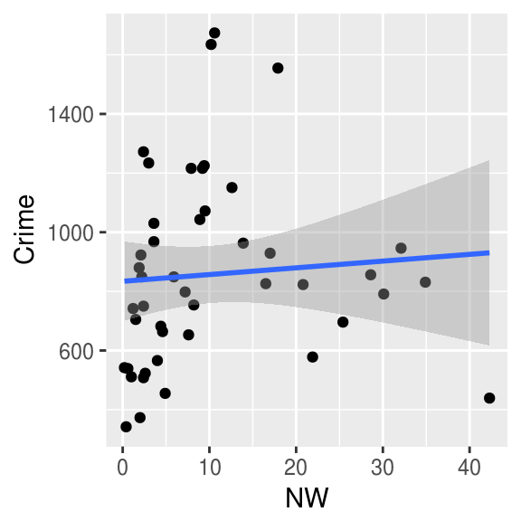

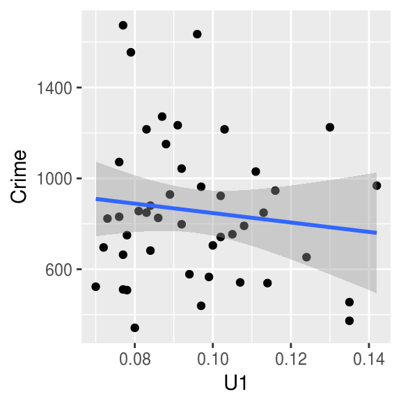

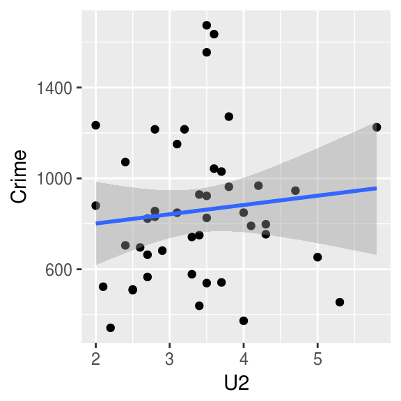

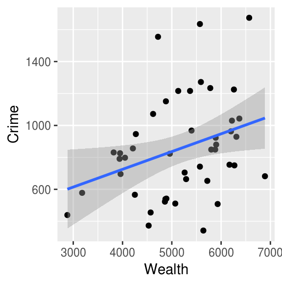

[3 more figures not shown]

```r
for (i in 1:(ncol(crime_desc)-1)){
  p= ggplot(data = crime_desc, aes(x=crime_desc[i], y = crime_desc$Crime))+geom_point()+geom_smooth(method='lm')
  p = p + scale_x_continuous()+xlab(as.character(colnames(crime_desc)[i]))+ylab('Crime')
  print (p)
}
```

# Building the linear regression model

```r
# First I build the LM model with all the predictors
lm_model = lm(formula = Crime~., data = crime_desc)
summary(lm_model)
```

```
##
## Call:
## lm(formula = Crime ~ ., data = crime_desc)
##
## Residuals:
##     Min      1Q  Median      3Q     Max
## -381.84  -98.79   -6.45  106.81  536.88
##
## Coefficients:
##               Estimate Std. Error t value Pr(>|t|)
## (Intercept) -5.265e+03  1.880e+03  -2.801  0.00897 **
## M            7.363e+01  4.442e+01   1.658  0.10819
## So           7.028e+00  1.509e+02   0.047  0.96318
## Ed           1.721e+02  6.454e+01   2.666  0.01241 *
## Po1          1.964e+02  1.183e+02   1.660  0.10763
## Po2         -1.152e+02  1.262e+02  -0.913  0.36900
## LF          -5.473e+02  1.492e+03  -0.367  0.71646
## M.F          1.449e+01  2.205e+01   0.657  0.51645
## Pop         -1.468e+00  1.560e+00  -0.941  0.35440
## NW           4.452e+00  6.584e+00   0.676  0.50430
## U1          -5.795e+03  4.368e+03  -1.327  0.19499
## U2           1.634e+02  8.574e+01   1.905  0.06672 .
## Wealth       8.985e-02  1.061e-01   0.847  0.40412
## Ineq         6.671e+01  2.332e+01   2.860  0.00777 **
## Prob        -4.865e+03  2.316e+03  -2.101  0.04447 *
## Time        -2.638e+00  7.342e+00  -0.359  0.72199
## ---
## Signif. codes:  0 '***' 0.001 '**' 0.01 '*' 0.05 '.' 0.1 ' ' 1
##
## Residual standard error: 211.7 on 29 degrees of freedom
## Multiple R-squared:  0.7089, Adjusted R-squared:  0.5583
## F-statistic: 4.708 on 15 and 29 DF,  p-value: 0.000177
```

From the sumamry of the linear model, we can see that a lot of predictors have a p-value significantly larger than the thershold of 0.05. The **adjusted R-squred** is **0.5583** Thus it is not appropriate to use all those predictors. I start to choose the predictors that have a p-value close to or smaller than 0.1. Thus I chose **M, Ed, Po1, U2, Ineq, Prob**.

```r
lm_model_1 = lm(Crime~M+Ed+Po1+U2+Ineq+Prob, data = crime_desc)
summary(lm_model_1)
```

```
##
## Call:
## lm(formula = Crime ~ M + Ed + Po1 + U2 + Ineq + Prob, data = crime_desc)
##
## Residuals:
##     Min      1Q  Median      3Q     Max
## -434.55  -94.97   -9.64  130.58  571.48
##
## Coefficients:
##             Estimate Std. Error t value Pr(>|t|)
## (Intercept) -4456.60    1016.64  -4.384 8.91e-05 ***
## M              94.65      34.44   2.748 0.009117 **
## Ed            175.39      48.05   3.650 0.000785 ***
## Po1           104.42      15.98   6.533 1.06e-07 ***
## U2             77.30      42.06   1.838 0.073915 .
## Ineq           63.25      14.48   4.367 9.36e-05 ***
## Prob        -4034.72    1554.74  -2.595 0.013365 *
## ---
## Signif. codes:  0 '***' 0.001 '**' 0.01 '*' 0.05 '.' 0.1 ' ' 1
##
## Residual standard error: 201.1 on 38 degrees of freedom
## Multiple R-squared:  0.6557, Adjusted R-squared:  0.6013
## F-statistic: 12.06 on 6 and 38 DF,  p-value: 1.517e-07
```

This time almost all the p-values for predictors are smaller than 0.05. The **adjusted R-squred** is **0.6013**, which is also improved.

I also tried another method called “stepwise” based on AIC. This **step** function can automatically select a model based on the AIC scores.

```r
# feed the linear regression model based on all predictors to the step function
step_lm_model = step(lm_model,trace = F)
summary(step_lm_model)
```

```
##
## Call:
## lm(formula = Crime ~ M + Ed + Po1 + Pop + U1 + U2 + Ineq + Prob,
##     data = crime_desc)
##
## Residuals:
##    Min     1Q Median     3Q    Max
## -510.4 -101.7    7.8  134.0  561.5
##
## Coefficients:
##              Estimate Std. Error t value Pr(>|t|)
## (Intercept) -4228.750   1017.823  -4.155 0.000191 ***
## M              84.109     35.053   2.400 0.021717 *
## Ed            182.211     51.708   3.524 0.001178 **
## Po1           106.301     20.030   5.307 5.86e-06 ***
## Pop            -1.656      1.269  -1.305 0.200192
## U1          -4438.862   3040.704  -1.460 0.153013
## U2            164.546     72.179   2.280 0.028654 *
## Ineq           64.822     14.530   4.461 7.69e-05 ***
## Prob        -4316.728   1554.422  -2.777 0.008653 **
## ---
## Signif. codes:  0 '***' 0.001 '**' 0.01 '*' 0.05 '.' 0.1 ' ' 1
##
## Residual standard error: 197.8 on 36 degrees of freedom
## Multiple R-squared:  0.6845, Adjusted R-squared:  0.6144
## F-statistic: 9.764 on 8 and 36 DF,  p-value: 4.398e-07
```

In the end, the step function chose 8 predictors to use. They are **M, Ed, Po1, Pop, U1, U2, Ineq, Prob**. This time the **adjusted R-squred** is **0.6144**.

I also tried Cross-Validation for this linear regression model.

```r
#load the DAAG package
library(DAAG)
# use 10 folds cross-validation for linear regression
cv_lm_model = cv.lm(data = crime_desc, form.lm = lm_model, m = 10)
```

```
## Analysis of Variance Table
##
## Response: Crime
##           Df  Sum Sq Mean Sq F value  Pr(>F)
## M          1   10132   10132    0.23  0.6379
## So         1    4762    4762    0.11  0.7467
## Ed         1  308774  308774    6.89  0.0137 *
## Po1        1 1613088 1613088   36.01 1.6e-06 ***
## Po2        1   72399   72399    1.62  0.2137
## LF         1   47636   47636    1.06  0.3110
## M.F        1   66095   66095    1.48  0.2343
## Pop        1     560     560    0.01  0.9117
## NW         1   14225   14225    0.32  0.5774
## U1         1    4772    4772    0.11  0.7465
## U2         1  261570  261570    5.84  0.0222 *
## Wealth     1   30069   30069    0.67  0.4193
## Ineq       1  485878  485878   10.85  0.0026 **
## Prob       1  237654  237654    5.30  0.0286 *
## Time       1    5783    5783    0.13  0.7220
## Residuals 29 1299160   44799
## ---
## Signif. codes:  0 '***' 0.001 '**' 0.01 '*' 0.05 '.' 0.1 ' ' 1
```

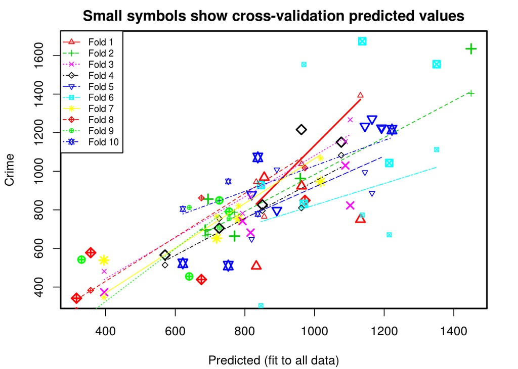

```
##
## fold 1
## Observations in test set: 4
##              15   19   30   43
## Predicted   856  963 1132  833
## cvpred      765 1038 1393  945
## Crime       968  923  750  508
## CV residual 203 -115 -643 -437
##
## Sum of squares = 658575    Mean square = 164644    n = 4
##
## fold 2
## Observations in test set: 5
##                4      16  21    33   35
## Predicted   1450 959.117 694 686.1  770
## cvpred      1404 963.716 673 665.5  788
## Crime       1635 963.000 856 696.0  664
## CV residual  231  -0.716 183  30.5 -124
##
## Sum of squares = 103093    Mean square = 20619    n = 5
##
## fold 3
## Observations in test set: 5
##               14   26    31   34   46
## Predicted   1089 1103 793.3  816  396
## cvpred      1154 1267 781.9  867  481
## Crime       1030  823 742.0  682  373
## CV residual -124 -444 -39.9 -185 -108
##
## Sum of squares = 260252    Mean square = 52050    n = 5
##
## fold 4
## Observations in test set: 5
##                9     11    25    32  38
## Predicted    962 1076.9 850.2 726.3 571
## cvpred       810 1083.1 796.2 754.9 514
## Crime       1216 1151.0 826.0 705.0 566
## CV residual  406   67.9  29.8 -49.9  52
##
## Sum of squares = 175455    Mean square = 35091    n = 5
```

[output cut: 49 more lines]

```
## Sum of squares = 271692    Mean square = 67923    n = 4
##
## fold 10
## Observations in test set: 4
##                  10   12   41   42
## Predicted   1222.45  837  622  752
## cvpred      1207.94  779  805  947
## Crime       1216.00 1072  523  511
## CV residual    8.06  293 -282 -436
##
## Sum of squares = 355789    Mean square = 88947    n = 4
##
## Overall (Sum over all 4 folds)
##    ms
## 1e+05
```

```r
# build the model based on the cross-validation results
lm_model_2 = lm(Crime~Ed + Po1 + Ineq + Prob, data = crime_desc)
summary(lm_model_2)
```

```
##
## Call:
## lm(formula = Crime ~ Ed + Po1 + Ineq + Prob, data = crime_desc)
##
## Residuals:
##    Min     1Q Median     3Q    Max
## -472.4 -123.8   13.3  131.8  485.1
##
## Coefficients:
##             Estimate Std. Error t value Pr(>|t|)
## (Intercept)  -2456.8      786.0   -3.13   0.0033 **
## Ed             126.2       46.6    2.71   0.0099 **
## Po1             98.3       16.7    5.88  7.0e-07 ***
## Ineq            70.3       15.1    4.67  3.3e-05 ***
## Prob         -3985.6     1669.9   -2.39   0.0218 *
## ---
## Signif. codes:  0 '***' 0.001 '**' 0.01 '*' 0.05 '.' 0.1 ' ' 1
##
## Residual standard error: 216 on 40 degrees of freedom
## Multiple R-squared:  0.581,  Adjusted R-squared:  0.539
## F-statistic: 13.9 on 4 and 40 DF,  p-value: 3.55e-07
```

After reviewing all the model I have built so far. I decided to use **M, Ed, Po1, Pop, U1, U2, Ineq, Prob** for my final model.

```r
# model formule
final_lm_model = lm(formula = Crime~M+Ed+Po1+Pop+U1+U2+Ineq+Prob, data = crime_desc)

# software output
summary(final_lm_model)
```

```
##
## Call:
## lm(formula = Crime ~ M + Ed + Po1 + Pop + U1 + U2 + Ineq + Prob,
##     data = crime_desc)
##
## Residuals:
##    Min     1Q Median     3Q    Max
## -510.4 -101.7    7.8  134.0  561.5
##
## Coefficients:
##              Estimate Std. Error t value Pr(>|t|)
## (Intercept) -4228.750   1017.823  -4.155 0.000191 ***
## M              84.109     35.053   2.400 0.021717 *
## Ed            182.211     51.708   3.524 0.001178 **
## Po1           106.301     20.030   5.307 5.86e-06 ***
## Pop            -1.656      1.269  -1.305 0.200192
## U1          -4438.862   3040.704  -1.460 0.153013
## U2            164.546     72.179   2.280 0.028654 *
## Ineq           64.822     14.530   4.461 7.69e-05 ***
## Prob        -4316.728   1554.422  -2.777 0.008653 **
## ---
## Signif. codes:  0 '***' 0.001 '**' 0.01 '*' 0.05 '.' 0.1 ' ' 1
##
## Residual standard error: 197.8 on 36 degrees of freedom
## Multiple R-squared:  0.6845, Adjusted R-squared:  0.6144
## F-statistic: 9.764 on 8 and 36 DF,  p-value: 4.398e-07
```

```r
# get the coefficients
final_lm_model$coefficients
```

```
##  (Intercept)            M           Ed          Po1          Pop
## -4228.750003    84.109465   182.210726   106.301475    -1.656482
##           U1           U2         Ineq         Prob
## -4438.861927   164.546015    64.822023 -4316.728243
```

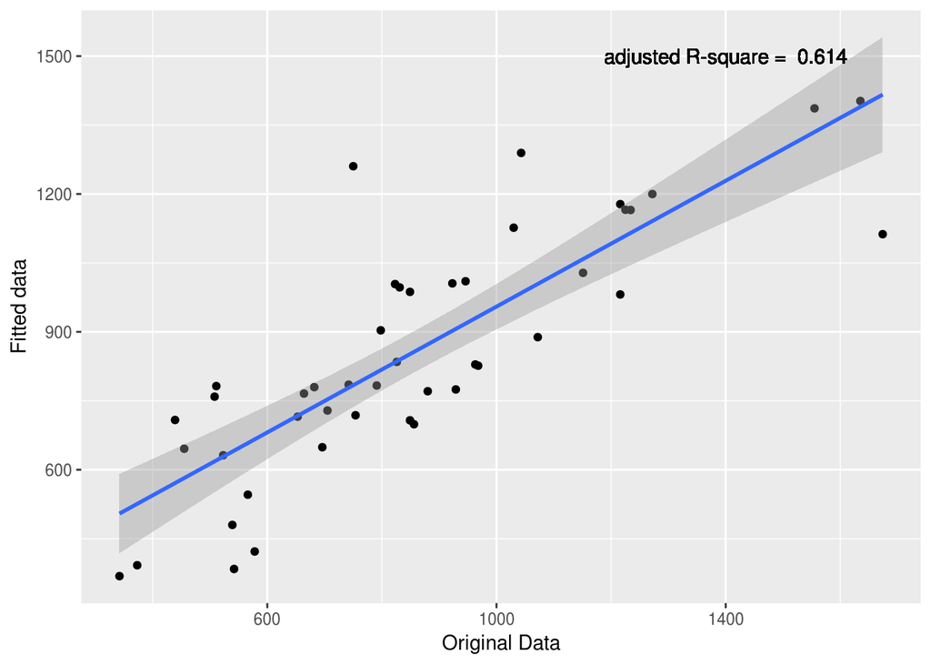

```r
# the quality of fit
p = ggplot(data = crime_desc, aes(x=Crime, y=final_lm_model$fitted.values))+geom_point()
p = p + geom_smooth(mapping = aes(x=Crime, y=final_lm_model$fitted.values),method = 'lm')
p = p + xlab('Original Data') + ylab('Fitted data') + geom_text(aes(1400, 1500), label = paste('adjusted R-square = ',round(summary(final_lm_model)$adj.r.squared,3)))
p
```

```r
# predict the value
newdata=data.frame(M = 14.0,So = 0,Ed = 10.0,Po1 = 12.0,Po2 = 15.5,LF = 0.640,M.F = 94.0,Pop = 150,NW = 1.1,U1 = 0.120,U2 = 3.6,Wealth = 3200,Ineq = 20.1,Prob = 0.04,Time = 39.0)

print (paste('The predicted Crime rate is:', round(predict(object = final_lm_model, newdata))))
```

```
## [1] "The predicted Crime rate is: 988"
```